# Informe técnico ESS6: Bienestar subjetivo en Europa

Mónica Pachón Basallo

2026-08-24

# 1 Introducción

La reproducibilidad constituye uno de los principios fundamentales de la ciencia de datos. Este proyecto utiliza datos de la European Social Survey (ESS Round 6) para analizar cómo diferentes factores sociodemográficos, familiares y económicos se relacionan con el bienestar subjetivo de la población europea.

El análisis se centra en diversas dimensiones del bienestar, incluyendo felicidad, salud percibida, relaciones sociales, autonomía personal y sentido vital. A partir del análisis exploratorio realizado en la Tarea 1 se identificaron los factores con mayor capacidad explicativa y se definió la estructura del dashboard interactivo desarrollado en el proyecto.

# 2 Objetivos

## 2.1 Objetivo general

Analizar la relación entre distintos factores sociodemográficos, familiares y económicos y el bienestar subjetivo de la población europea.

## 2.2 Objetivos específicos

1. Describir los niveles de bienestar subjetivo de la muestra.
2. Identificar las variables con mayor asociación con el bienestar subjetivo.
3. Comparar distintos perfiles de bienestar según características sociales y económicas.
4. Determinar qué variables deben ocupar un papel central en el dashboard.
5. Desarrollar productos reproducibles para la comunicación de resultados.

# 3 Datos y metodología

Los datos proceden de la European Social Survey Round 6 (ESS6), una encuesta multinacional realizada en diversos países europeos.

Para el desarrollo del proyecto se llevaron a cabo las siguientes tareas:

- Selección de variables relevantes para el estudio del bienestar subjetivo.
- Tratamiento de valores perdidos.
- Recodificación de variables categóricas y ordinales.
- Construcción de indicadores auxiliares para el análisis.
- Análisis exploratorio de datos (EDA).
- Desarrollo de un dashboard interactivo.
- Generación de productos reproducibles mediante R Markdown.

La misma base de datos depurada se ha utilizado en todas las fases del proyecto, garantizando la coherencia entre el análisis exploratorio, el dashboard y los documentos de comunicación.

# 4 Carga de datos

```r
library(dplyr)
library(readr)
library(ggplot2)
library(knitr)
library(tidyr)

df <- read_csv(
  "../Datos/depurada/base_final_reto2.csv",
  show_col_types = FALSE
)
```

# 5 Descripción de la muestra

La base final contiene **54.673** observaciones y **36** variables.

La edad media observada es de **48.3** años.

La felicidad media registrada es de **7.11** puntos sobre una escala de 0 a 10.

La puntuación media de felicidad observada en la muestra es de **7.11** puntos sobre 10, lo que indica niveles relativamente elevados de bienestar subjetivo entre los participantes de la encuesta.

# 6 Hallazgo principal del proyecto

El análisis exploratorio realizado durante la Tarea 1 permitió identificar un patrón muy claro en los datos: las diferencias más importantes en bienestar subjetivo aparecen asociadas principalmente a dos factores estructurales:

- La percepción de ingresos del hogar.
- El nivel educativo.

En prácticamente todas las dimensiones analizadas, las personas que perciben una situación económica más favorable y aquellas con niveles educativos más elevados presentan mayores niveles de felicidad, mejor salud percibida, una valoración más positiva de su vida y mayores niveles de autonomía personal.

Por el contrario, variables como sexo, convivencia en pareja, presencia de hijos o antecedentes de divorcio muestran diferencias más moderadas y se utilizan principalmente como variables de segmentación dentro del dashboard interactivo.

# 7 Estadísticos descriptivos de felicidad

La felicidad constituye el indicador sintético principal de bienestar utilizado en el proyecto. No obstante, el análisis no se limita a esta dimensión, sino que incorpora otros indicadores relacionados con la salud percibida, la integración social, la autonomía personal y el sentido vital.

Por este motivo, las visualizaciones desarrolladas permiten analizar perfiles multidimensionales de bienestar en lugar de una única variable aislada.

```r
resumen_happy <- df %>%
  summarise(
    Casos = sum(!is.na(happy)),
    Media = round(mean(happy, na.rm = TRUE), 2),
    Mediana = median(happy, na.rm = TRUE),
    Desv_Tipica = round(sd(happy, na.rm = TRUE), 2),
    Minimo = min(happy, na.rm = TRUE),
    Maximo = max(happy, na.rm = TRUE)
  )

kable(
  resumen_happy,
  caption = "Estadísticos descriptivos de felicidad"
)
```

Estadísticos descriptivos de felicidad

| Casos | Media | Mediana | Desv_Tipica | Minimo | Maximo |
| --- | --- | --- | --- | --- | --- |
| 54228 | 7.11 | 8 | 2.1 | 0 | 10 |

Los resultados muestran niveles relativamente elevados de bienestar subjetivo en la muestra analizada.

# 8 Bienestar subjetivo y situación económica

La percepción económica del hogar constituye el factor que presenta la asociación más clara con los indicadores de bienestar analizados.

A medida que mejora la valoración de la situación económica doméstica aumentan los niveles medios de felicidad, salud percibida y autonomía personal.

```r
tabla_ingresos <- df %>%
  filter(!is.na(hincfel)) %>%
  group_by(hincfel) %>%
  summarise(
    Participantes = n(),
    Felicidad_media = round(mean(happy, na.rm = TRUE), 2),
    Salud_media = round(mean(health_num, na.rm = TRUE), 2),
    Libertad_media = round(mean(dclvlf, na.rm = TRUE), 2),
    .groups = "drop"
  )

kable(
  tabla_ingresos,
  caption = "Indicadores medios según percepción económica"
)
```

Indicadores medios según percepción económica

| hincfel | Participantes | Felicidad_media | Salud_media | Libertad_media |
| --- | --- | --- | --- | --- |
| Dificultad | 12157 | 6.42 | 3.51 | 2.14 |
| Mucha dificultad | 5915 | 5.18 | 3.24 | 2.38 |
| Muy satisfecho | 12785 | 8.13 | 4.10 | 1.78 |
| Satisface | 23120 | 7.40 | 3.81 | 1.93 |

La categoría con mayor bienestar corresponde a los participantes que declaran una situación económica más favorable, mientras que los niveles más bajos aparecen entre quienes manifiestan mayores dificultades económicas.

# 9 Principal resultado del proyecto

La percepción económica del hogar constituye el principal eje de desigualdad observado en los datos.

La siguiente visualización resume simultáneamente distintas dimensiones del bienestar subjetivo y permite observar cómo cambian los perfiles de bienestar a medida que mejora la percepción económica de los ingresos del hogar.

Este resultado fue determinante para el diseño del dashboard final, donde la situación económica se incorpora como una de las variables explicativas principales.

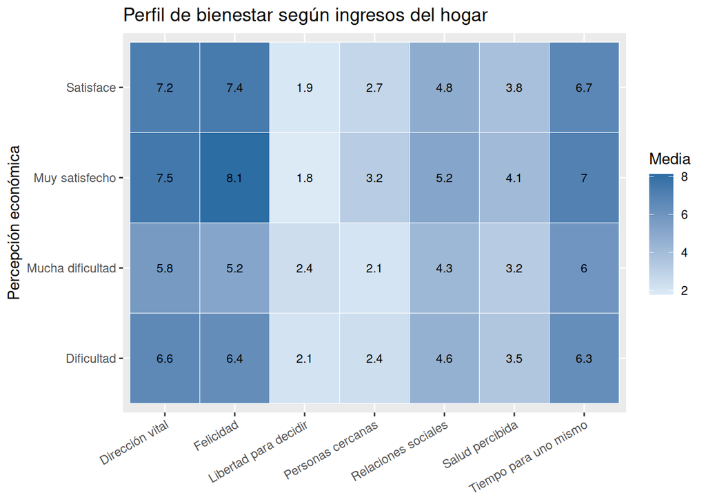

```r
vars_bienestar <- c(
  "happy",
  "sclmeet",
  "inprdsc",
  "dclvlf",
  "tmdotwa",
  "sedirlf",
  "health_num"
)

etiquetas <- c(
  happy = "Felicidad",
  sclmeet = "Relaciones sociales",
  inprdsc = "Personas cercanas",
  dclvlf = "Libertad para decidir",
  tmdotwa = "Tiempo para uno mismo",
  sedirlf = "Dirección vital",
  health_num = "Salud percibida"
)

df_heat_ingresos <- df %>%
  filter(!is.na(hincfel)) %>%
  group_by(hincfel) %>%
  summarise(
    across(
      all_of(vars_bienestar),
      ~ mean(.x, na.rm = TRUE)
    ),
    .groups = "drop"
  ) %>%
  pivot_longer(
    cols = -hincfel,
    names_to = "indicador",
    values_to = "media"
  ) %>%
  mutate(
    indicador = recode(indicador, !!!etiquetas)
  )

ggplot(
  df_heat_ingresos,
  aes(
    x = indicador,
    y = hincfel,
    fill = media
  )
) +
  geom_tile(color = "white") +
  geom_text(
    aes(label = round(media, 1)),
    size = 3
  ) +
  scale_fill_gradient(
    low = "#DCEAF6",
    high = "#2C6DA4"
  ) +
  labs(
    title = "Perfil de bienestar según ingresos del hogar",
    x = NULL,
    y = "Percepción económica",
    fill = "Media"
  ) +
  theme(
    axis.text.x = element_text(
      angle = 30,
      hjust = 1
    )
  )
```

# 10 Bienestar subjetivo y nivel educativo

El nivel educativo constituye el segundo gran factor explicativo identificado durante el análisis exploratorio.

```r
tabla_educacion <- df %>%
  filter(!is.na(eisced)) %>%
  group_by(eisced) %>%
  summarise(
    Participantes = n(),
    Felicidad_media = round(mean(happy, na.rm = TRUE), 2),
    Salud_media = round(mean(health_num, na.rm = TRUE), 2),
    Libertad_media = round(mean(dclvlf, na.rm = TRUE), 2),
    .groups = "drop"
  )

kable(
  tabla_educacion,
  caption = "Indicadores medios según nivel educativo"
)
```

Indicadores medios según nivel educativo

| eisced | Participantes | Felicidad_media | Salud_media | Libertad_media |
| --- | --- | --- | --- | --- |
| Formación avanzada / subgrado | 7348 | 7.14 | 3.77 | 1.97 |
| Menos que secundaria inferior | 5897 | 6.81 | 3.26 | 2.09 |
| Secundaria inferior | 9819 | 6.93 | 3.67 | 2.06 |
| Secundaria superior (nivel alto) | 12162 | 6.89 | 3.83 | 1.99 |
| Secundaria superior (nivel bajo) | 7353 | 7.28 | 3.73 | 1.99 |
| Terciaria inferior / grado | 5019 | 7.71 | 4.10 | 1.87 |
| Terciaria superior / máster+ | 6711 | 7.36 | 3.91 | 1.91 |

# 11 Perfil de bienestar según nivel educativo

La siguiente visualización resume el perfil medio de bienestar para los distintos niveles educativos.

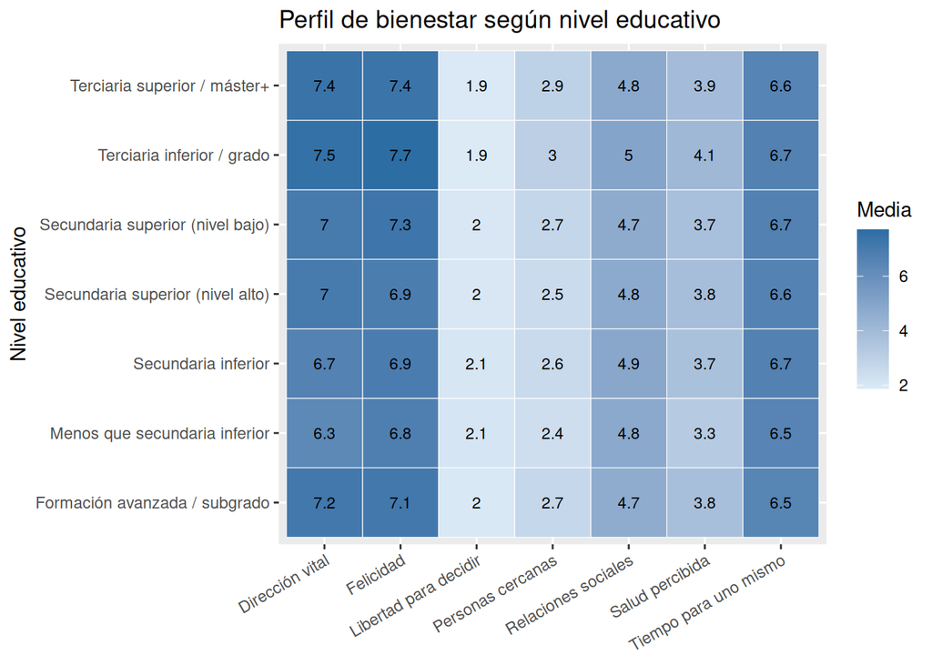

```r
df_heat_educ <- df %>%
  filter(!is.na(eisced)) %>%
  group_by(eisced) %>%
  summarise(
    across(
      all_of(vars_bienestar),
      ~ mean(.x, na.rm = TRUE)
    ),
    .groups = "drop"
  ) %>%
  pivot_longer(
    cols = -eisced,
    names_to = "indicador",
    values_to = "media"
  ) %>%
  mutate(
    indicador = recode(indicador, !!!etiquetas)
  )

ggplot(
  df_heat_educ,
  aes(
    x = indicador,
    y = eisced,
    fill = media
  )
) +
  geom_tile(color = "white") +
  geom_text(
    aes(label = round(media, 1)),
    size = 3
  ) +
  scale_fill_gradient(
    low = "#DCEAF6",
    high = "#2C6DA4"
  ) +
  labs(
    title = "Perfil de bienestar según nivel educativo",
    x = NULL,
    y = "Nivel educativo",
    fill = "Media"
  ) +
  theme(
    axis.text.x = element_text(
      angle = 30,
      hjust = 1
    )
  )
```

Los resultados observados para educación refuerzan los patrones detectados para la situación económica.

# 12 Variables contextuales consideradas

Además de la educación y la situación económica, el análisis exploró diversas variables sociodemográficas y familiares.

[output not shown]

Las diferencias más relevantes se concentran en los ejes económico y educativo. Las variables familiares y sociodemográficas aportan información complementaria y enriquecen la interpretación de los resultados.

# 13 Justificación del dashboard

El dashboard desarrollado en este proyecto se construye directamente a partir de los resultados obtenidos durante el análisis exploratorio.

Los hallazgos permitieron identificar dos grandes ejes explicativos del bienestar subjetivo:

- La percepción de ingresos del hogar.
- El nivel educativo.

Por esta razón, ambas variables se utilizan como mecanismos principales de comparación dentro de la visualización interactiva.

Además, el análisis mostró que variables como sexo, edad, convivencia en pareja, presencia de hijos y antecedentes de divorcio aportan contexto adicional y permiten explorar diferencias entre subgrupos específicos. Estas variables se incorporan principalmente como filtros y herramientas de segmentación.

## 13.1 Indicadores de bienestar representados

- Felicidad global.
- Salud percibida.
- Dirección vital.
- Libertad para decidir.
- Tiempo para uno mismo.
- Frecuencia de reuniones sociales.
- Red de apoyo íntimo.

## 13.2 Variables explicativas principales

- Percepción de ingresos del hogar.
- Nivel educativo.

## 13.3 Variables de segmentación y filtrado

- Sexo.
- Edad.
- Convivencia en pareja.
- Presencia de hijos.
- Antecedente de divorcio.
- País de residencia.

# 14 Conclusiones

El análisis realizado sobre los datos de la European Social Survey (ESS6) confirma la existencia de desigualdades relevantes en bienestar subjetivo asociadas principalmente a factores socioeconómicos y educativos.

La percepción de ingresos del hogar constituye el factor más estrechamente relacionado con las diferencias observadas en felicidad, salud percibida, autonomía personal, relaciones sociales y sentido vital. Las personas que perciben una situación económica favorable muestran sistemáticamente perfiles de bienestar más positivos.

Las variables familiares y sociodemográficas muestran asociaciones más moderadas. Aunque no explican gran parte de las diferencias observadas, sí aportan contexto y permiten explorar cómo se manifiestan las desigualdades de bienestar en distintos grupos de población.

En conjunto, estos resultados justifican la estructura analítica adoptada en el dashboard interactivo, que prioriza ingresos y educación como variables explicativas principales e incorpora filtros sociodemográficos para facilitar la exploración de patrones específicos.

Los resultados obtenidos son coherentes con los patrones identificados durante el Reto 1 y sirvieron como base para la selección de variables, filtros y visualizaciones incorporadas posteriormente en el dashboard interactivo.

El proyecto demuestra cómo un proceso reproducible de preparación, análisis y visualización de datos puede contribuir a comprender mejor las desigualdades en bienestar subjetivo presentes en la población europea. ``